# Introduction to R for Data Science Part IV

## `ggplot2` scatter plots with text

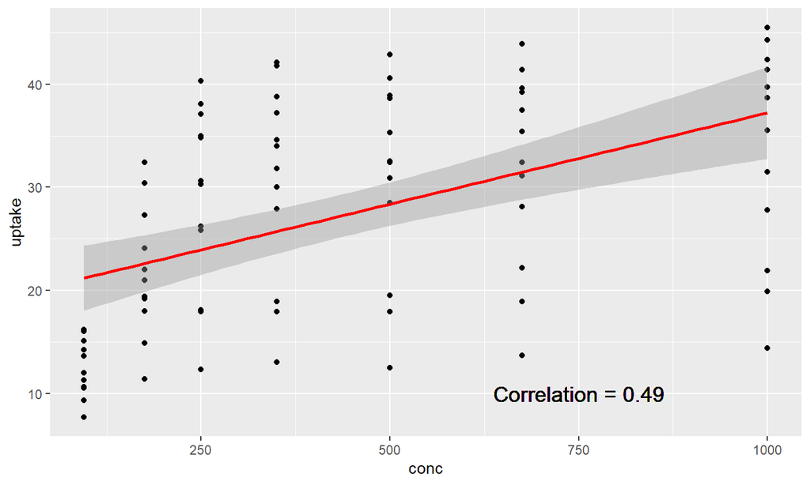

```r
correlation <- cor(CO2$conc, CO2$uptake)
ggplot(CO2, aes(x = conc, y = uptake)) + geom_point() +
  geom_smooth(method = lm, col = "Red") +
  geom_text(x = 750, y = 10, size = 5,
            label = paste0("Correlation = ", round(correlation, 2)))
```

## `ggplot2` scatter plots with text points

- Text for points with `geom_text`

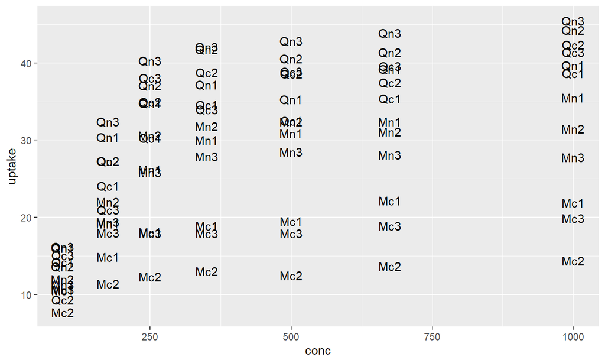

```r
ggplot(CO2, aes(x = conc, y = uptake)) +
  geom_text(aes(label = Plant))
```

## `ggplot2` faceting

- Easily facet! (Note: `cut()` is useful for categorizing a numeric variable)

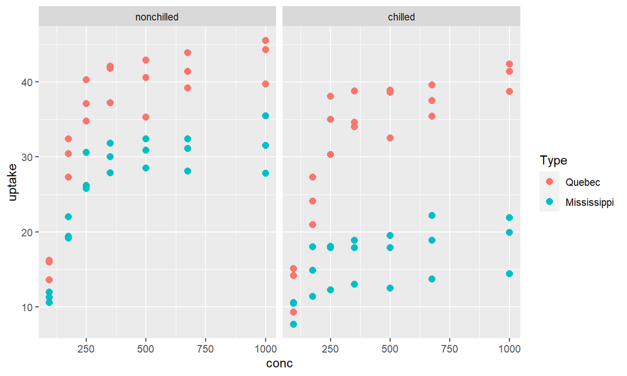

```r
ggplot(CO2, aes(x = conc, y = uptake)) +
  geom_point(aes(color = Type), size = 2.5) +
  facet_wrap(~ Treatment)
```

## `ggpairs`

- Saw `pairs`, better with `GGally::ggpairs()`

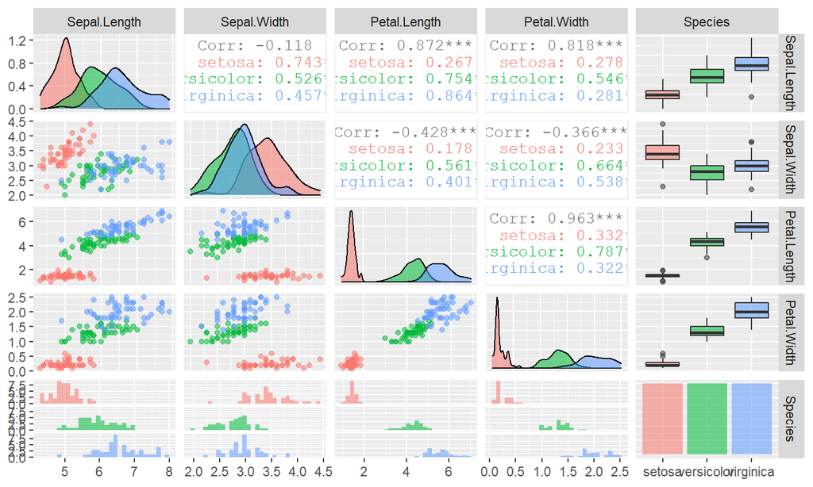

```r
library(GGally) #install GGally if needed
ggpairs(iris, aes(colour = Species, alpha = 0.4))
```

## `ggplot2` Plotting: Numeric variables

Recap!

Numeric variable - entries are a numerical value where math can be performed

Most common plots:

- Histogram (`geom_hist`), Density (`geom_density`)
- Boxplot (`geom_boxplot`)
- Scatter plot (`geom_point`), Smoothers (`geom_smooth`)
- Jittered points (`geom_jitter`)
- Text on plot (`geom_text`)

## `ggplot2` Plotting Recap

General `ggplot` things:

- Can set local or global `aes`
- Modify titles/labels by adding more layers
- Use either stat or geom layer
- Faceting (multiple plots) via `facet_grid` or `facet_wrap`
- Only need `aes` if setting a mapping value that is dependent on the data (or you want to create a custom legend!)

## Recap!

`ggplot(data = <DATA>) +`  
`<GEOM_FUNCTION>(mapping = aes(<MAPPINGS>), stat = <STAT>, position = <POSITION>) +`  
`<COORDINATE_FUNCTION> +`  
`<FACET_FUNCTION> +`  
`<LABEL_FUNCTION>`  
`)`

- Lots of extensions to ggplot!
  - `gganimate`
  - `ggthemes`
  - `ggmap`
  - `ggrepel`

## Activity

- [**ggplot Activity** instructions](http://www4.stat.ncsu.edu/~post/DataScienceR/ggplotActivity.html) available on web
- We’ll send you to breakout rooms
- One TA or instructor in each room to help out
- Feel free to ask questions about anything you didn’t understand as well!

## Schedule

**Day 2**

- Logical Statements and Subsetting/Manipulating Data?
- Numerical and Graphical Summaries
- **Basic Analyses**

## Basic Analysis (Linear Regression)

- With multiple quantitative varibles can look at many types of relationships
- Investigated linear relationship between two with correlation
- Scatter Plot gives useful visualization
- Consider data on voting preferences by county
  - Inspect relationship with pct with college degree and income

## Basic Analysis (Linear Regression)

- With multiple quantitative varibles can look at many types of relationships
- Investigated linear relationship between two with correlation
- Scatter Plot gives useful visualization
- Consider data on voting preferences by county
  - Inspect relationship with pct with college degree and income

```r
voting <- read_csv("datasets/counties.csv")
```

## Basic Analysis (Linear Regression)

```r
voting
```

```
## # A tibble: 3,141 x 20
##   region county state   msa  pmsa pop.density   pop pop.change age6574 age75
##   <chr>  <chr>  <chr> <dbl> <dbl>       <dbl> <dbl>      <dbl>   <dbl> <dbl>
## 1 South  Autau~ AL     5240    NA          61 34222      11.9     5.70  4.10
## 2 South  Baldw~ AL     5160    NA          67 98280      35.4     9.20  6
## 3 South  Barbo~ AL       NA    NA          29 25417       2       8.20  6.40
## 4 South  Bibb   AL       NA    NA          28 16576       9.20    6.70  6
## 5 South  Blount AL     1000    NA          62 39248      10.6     7.40  5.60
## # ... with 3,136 more rows, and 10 more variables: crime <dbl>, college <dbl>,
## #   income <dbl>, farm <dbl>, democrat <dbl>, republican <dbl>, Perot <dbl>,
## #   white <dbl>, black <dbl>, turnout <dbl>
```

## Basic Analysis (Linear Regression)

- Create a scatter plot, add correlation

```r
votePlot <- ggplot(voting, aes(x = college, y = income))
```

```r
votePlot +
  geom_point()+
  geom_text(x = 40, y = 15000,
            label = round(cor(voting$college, voting$income), 2))
```

## Basic Analysis (Linear Regression)

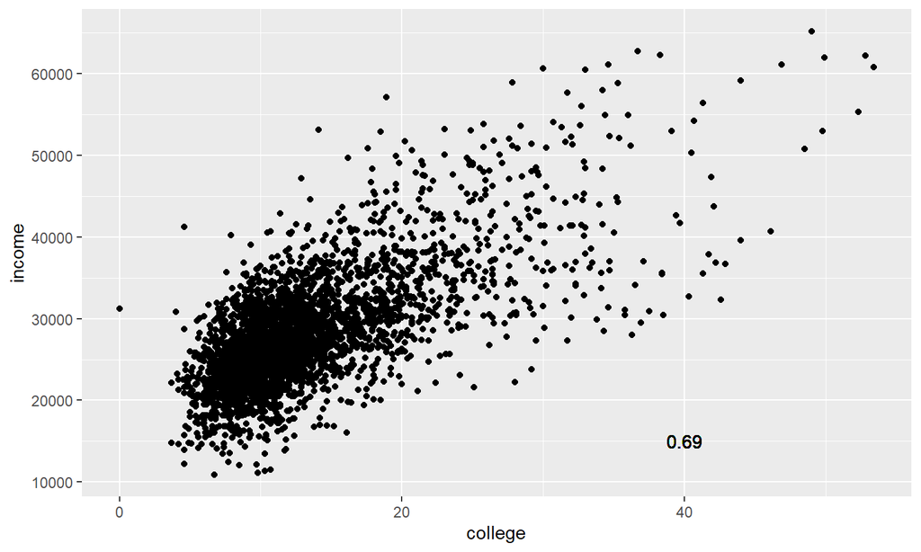

## Basic Analysis (Linear Regression)

- Often want to predict y variable using a value of x
- **Simple Linear Regression** allows for this
- Linear model for predicting income based on college:
- cty_income = int + slope * (% college in county) + random_error
- Generally, response (Y) = function of predictors (features, X’s) + error
  $$Y_i=\beta_0+\beta_1 x_{1i}+…+\beta_p x_{pi}+E_i$$

## Basic Analysis (Linear Regression)

- Fit simple linear regression model using `lm()`

```r
lm(income ~ college, data = voting)
```

```
##
## Call:
## lm(formula = income ~ college, data = voting)
##
## Coefficients:
## (Intercept)      college
##     18305.5        752.6
```

## Basic Analysis (Linear Regression)

- Save as object, check attributes

```r
fit <- lm(income ~ college, data = voting)
attributes(fit)
```

```
## $names
##  [1] "coefficients"  "residuals"     "effects"       "rank"
##  [5] "fitted.values" "assign"        "qr"            "df.residual"
##  [9] "xlevels"       "call"          "terms"         "model"
##
## $class
## [1] "lm"
```

## Basic Analysis (Linear Regression)

- Three main ways to get at *many* of these attributes

```r
fit[[1]]
```

```
## (Intercept)     college
##  18305.5294    752.6481
```

```r
coefficients(fit)
```

```
## (Intercept)     college
##  18305.5294    752.6481
```

```r
fit$coefficients
```

```
## (Intercept)     college
##  18305.5294    752.6481
```

## Basic Analysis (Linear Regression)

- Three main ways to get at *many* of these attributes

```r
fit[[2]]
residuals(fit)
fit$residuals
```

## Basic Analysis (Linear Regression)

- Three main ways to get at *many* of these attributes

```r
#no generic function for some things
rank(fit)
```

```
## Error in rank(fit): unimplemented type 'list' in 'greater'
```

```r
y(fit)
```

```
## Error in y(fit): could not find function "y"
```

```r
fit$rank
```

```
## [1] 2
```

## Basic Analysis (Linear Regression)

- Statistical analysis found using `anova()` or `summary()`

```r
#ANOVA table (F tests)
anova(fit)
```

```
## Analysis of Variance Table
##
## Response: income
##             Df     Sum Sq    Mean Sq F value    Pr(>F)
## college      1 7.6911e+10 7.6911e+10  2865.4 < 2.2e-16 ***
## Residuals 3139 8.4254e+10 2.6841e+07
## ---
## Signif. codes:  0 '***' 0.001 '**' 0.01 '*' 0.05 '.' 0.1 ' ' 1
```

## Basic Analysis (Linear Regression)

- Statistical analysis found using `anova()` or `summary()`

```r
#coefficient type III tests
summary(fit)
```

```
##
## Call:
## lm(formula = income ~ college, data = voting)
##
## Residuals:
##      Min       1Q   Median       3Q      Max
## -18062.3  -3146.8   -288.8   2890.7  24569.4
##
## Coefficients:
##             Estimate Std. Error t value Pr(>|t|)
## (Intercept) 18305.53     211.29   86.64   <2e-16 ***
## college       752.65      14.06   53.53   <2e-16 ***
## ---
## Signif. codes:  0 '***' 0.001 '**' 0.01 '*' 0.05 '.' 0.1 ' ' 1
##
## Residual standard error: 5181 on 3139 degrees of freedom
## Multiple R-squared:  0.4772, Adjusted R-squared:  0.4771
## F-statistic:  2865 on 1 and 3139 DF,  p-value: < 2.2e-16
```

## Basic Analysis (Linear Regression)

- Diagnostic plots easily found using `plot()`
- Run this code in console

```r
plot(fit)
```

## Basic Analysis (Linear Regression)

- Add fit to our scatter plot
- Compare to a smoothed fit

```r
votePlot +
  geom_point() +
  geom_smooth(method = "lm") +
  geom_smooth()
```

## Basic Analysis (Linear Regression)

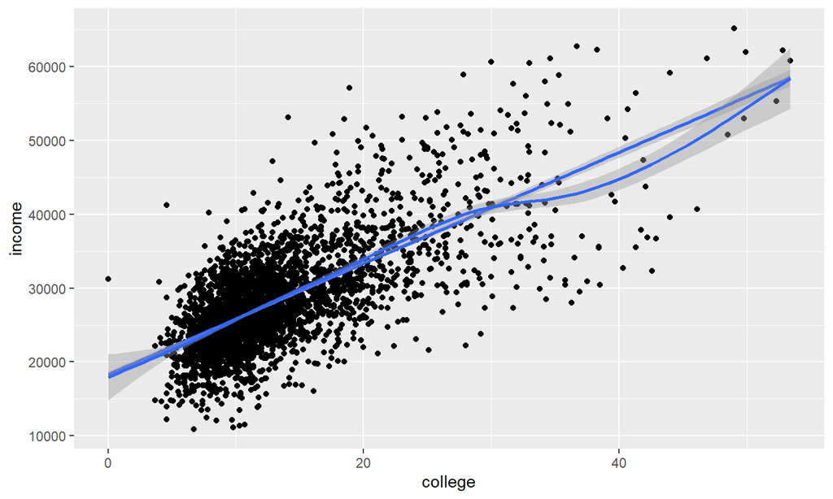

## Basic Analysis (Linear Regression)

- Now can predict y for a given x
- Check `help(predict)`, particularly `predict.lm()`

```r
predict(fit, newdata = data.frame(college = c(40, 10)))
```

```
##        1        2
## 48411.45 25832.01
```

## Basic Analysis (Linear Regression)

- Get SE for prediction

```r
predict(fit, newdata = data.frame(college = c(40, 10)), se.fit = TRUE)
```

```
## $fit
##        1        2
## 48411.45 25832.01
##
## $se.fit
##        1        2
## 383.7192 104.8104
##
## $df
## [1] 3139
##
## $residual.scale
## [1] 5180.841
```

## Basic Analysis (Linear Regression)

- Get confidence interval for mean response

```r
predict(fit, newdata = data.frame(college = c(40, 10)),
        se.fit = TRUE, interval = "confidence")
```

```
## $fit
##        fit      lwr      upr
## 1 48411.45 47659.09 49163.82
## 2 25832.01 25626.51 26037.51
##
## $se.fit
##        1        2
## 383.7192 104.8104
##
## $df
## [1] 3139
##
## $residual.scale
## [1] 5180.841
```

## Basic Analysis (Linear Regression)

- Get prediction interval for new response

```r
predict(fit, newdata = data.frame(college = c(40, 10)),
        se.fit = TRUE, interval = "prediction")
```

```
## $fit
##        fit      lwr      upr
## 1 48411.45 38225.45 58597.45
## 2 25832.01 15671.75 35992.27
##
## $se.fit
##        1        2
## 383.7192 104.8104
##
## $df
## [1] 3139
##
## $residual.scale
## [1] 5180.841
```

## Basic Analysis (Linear Regression)

- Multiple Linear Regression (more than one x)
- In `lm()`
  - add “main effect” terms with `+ name`
  - interactions with `+ name1:name2`
  - all possible combinations with `+ name1*name2`

```r
fit2<-lm(income ~ college + Perot, data = voting)
```

## Basic Analysis (Linear Regression)

- Multiple Linear Regression (more than one x)

```r
anova(fit2)
```

```
## Analysis of Variance Table
##
## Response: income
##             Df     Sum Sq    Mean Sq  F value    Pr(>F)
## college      1 7.4771e+10 7.4771e+10 3013.718 < 2.2e-16 ***
## Perot        1 2.0739e+09 2.0739e+09   83.591 < 2.2e-16 ***
## Residuals 3111 7.7185e+10 2.4810e+07
## ---
## Signif. codes:  0 '***' 0.001 '**' 0.01 '*' 0.05 '.' 0.1 ' ' 1
```

## Basic Analysis (Linear Regression)

```r
summary(fit2)
```

```
##
## Call:
## lm(formula = income ~ college + Perot, data = voting)
##
## Residuals:
##    Min     1Q Median     3Q    Max
## -17192  -3205   -234   2909  21077
##
## Coefficients:
##             Estimate Std. Error t value Pr(>|t|)
## (Intercept) 16167.90     310.46  52.077   <2e-16 ***
## college       728.46      13.71  53.136   <2e-16 ***
## Perot         119.73      13.10   9.143   <2e-16 ***
## ---
## Signif. codes:  0 '***' 0.001 '**' 0.01 '*' 0.05 '.' 0.1 ' ' 1
##
## Residual standard error: 4981 on 3111 degrees of freedom
##   (27 observations deleted due to missingness)
## Multiple R-squared:  0.4989, Adjusted R-squared:  0.4986
## F-statistic:  1549 on 2 and 3111 DF,  p-value: < 2.2e-16
```

## Basic Analysis (Linear Regression)

- Access elements of object just as before

```r
coef(fit2)
```

```
## (Intercept)     college       Perot
##  16167.9032    728.4587    119.7262
```

```r
fit2$rank
```

```
## [1] 3
```

## Basic Analysis (Linear Regression)

- Basic diagnostic plots (run in console)

```r
plot(fit2)
```

## Basic Analysis (Linear Regression)

- Predict new for new values

```r
predict(fit2, newdata = data.frame(college = c(40, 30), Perot = c(20, 25)))
```

```
##        1        2
## 47700.77 41014.82
```

##Recap!

- Basic linear regression
  - Use `lm()`
- Statistical analysis
  - `anova()`
  - `summary()`
- Predict using `predict()`
- Add fits to scatter plot with `geom_smooth(method = "lm")`

## Activity

- [**Basic Analysis Activity** instructions](http://www4.stat.ncsu.edu/~post/DataScienceR/AnalysisActivity.html) available on web
- We’ll send you to breakout rooms
- One TA or instructor in each room to help out
- Feel free to ask questions about anything you didn’t understand as well!
- Thanks for coming!!